## 2. Data Preparation

The `day.csv` dataset was imported into R. The dimensions and structure of the dataset were examined to check the number of observations and variables and to identify how each variable was stored in R.

```r
# Import the dataset
bike <- read.csv("day.csv")

# Check dimensions and original structure
dim(bike)
```

```
## [1] 731  16
```

```r
str(bike)
```

```
## 'data.frame':    731 obs. of  16 variables:
##  $ instant   : int  1 2 3 4 5 6 7 8 9 10 ...
##  $ dteday    : chr  "2011-01-01" "2011-01-02" "2011-01-03" "2011-01-04" ...
##  $ season    : int  1 1 1 1 1 1 1 1 1 1 ...
##  $ yr        : int  0 0 0 0 0 0 0 0 0 0 ...
##  $ mnth      : int  1 1 1 1 1 1 1 1 1 1 ...
##  $ holiday   : int  0 0 0 0 0 0 0 0 0 0 ...
##  $ weekday   : int  6 0 1 2 3 4 5 6 0 1 ...
##  $ workingday: int  0 0 1 1 1 1 1 0 0 1 ...
##  $ weathersit: int  2 2 1 1 1 1 2 2 1 1 ...
##  $ temp      : num  0.344 0.363 0.196 0.2 0.227 ...
##  $ atemp     : num  0.364 0.354 0.189 0.212 0.229 ...
##  $ hum       : num  0.806 0.696 0.437 0.59 0.437 ...
##  $ windspeed : num  0.16 0.249 0.248 0.16 0.187 ...
##  $ casual    : int  331 131 120 108 82 88 148 68 54 41 ...
##  $ registered: int  654 670 1229 1454 1518 1518 1362 891 768 1280 ...
##  $ cnt       : int  985 801 1349 1562 1600 1606 1510 959 822 1321 ...
```

The dataset contains 731 observations and 16 variables. The initial structure showed that `dteday` was stored as a character variable. The categorical variables `season`, `yr`, `mnth`, `holiday`, `weekday`, `workingday`, and `weathersit` were stored as integers.

### Missing Values and Possible Inconsistencies

The dataset was checked for missing values, duplicate observations, and possible inconsistencies. The values of the categorical variables were checked to make sure they were within their expected categories. The total rental count was also checked to confirm that it was equal to the sum of casual and registered users.

```r
# Check missing values
colSums(is.na(bike))
```

```
##    instant     dteday     season         yr       mnth    holiday    weekday
##          0          0          0          0          0          0          0
## workingday weathersit       temp      atemp        hum  windspeed     casual
##          0          0          0          0          0          0          0
## registered        cnt
##          0          0
```

```r
# Check duplicate observations
sum(duplicated(bike))
```

```
## [1] 0
```

```r
# Check categorical values
unique(bike$season)
```

```
## [1] 1 2 3 4
```

```r
unique(bike$yr)
```

```
## [1] 0 1
```

```r
unique(bike$mnth)
```

```
##  [1]  1  2  3  4  5  6  7  8  9 10 11 12
```

```r
unique(bike$holiday)
```

```
## [1] 0 1
```

```r
unique(bike$weekday)
```

```
## [1] 6 0 1 2 3 4 5
```

```r
unique(bike$workingday)
```

```
## [1] 0 1
```

```r
unique(bike$weathersit)
```

```
## [1] 2 1 3
```

```r
# Check consistency of total rental count
all(bike$cnt == bike$casual + bike$registered)
```

```
## [1] TRUE
```

No missing values or duplicate observations were found. The categorical variables contained values within their expected ranges. `season` contained values 1–4, `yr` contained 0–1, `mnth` contained 1–12, `holiday` contained 0–1, `weekday` contained 0–6, `workingday` contained 0–1, and `weathersit` contained 1–3. In addition, `cnt` was equal to the sum of `casual` and `registered` for every observation. Therefore, no clear coding errors or inconsistencies were identified.

### Unusual Observations

Potentially unusual observations in the numerical variables were identified using the standard boxplot rule.

```r
# Identify potential unusual observations
boxplot.stats(bike$temp)$out
```

```
## numeric(0)
```

```r
boxplot.stats(bike$atemp)$out
```

```
## numeric(0)
```

```r
boxplot.stats(bike$hum)$out
```

```
## [1] 0.187917 0.000000
```

```r
boxplot.stats(bike$windspeed)$out
```

```
##  [1] 0.417908 0.507463 0.385571 0.388067 0.422275 0.415429 0.409212 0.421642
##  [9] 0.441563 0.414800 0.386821 0.398008 0.407346
```

```r
boxplot.stats(bike$casual)$out
```

```
##  [1] 2355 2282 3065 2418 2521 2397 3155 2469 2301 2347 3252 2795 2846 2541 2496
## [16] 2622 3410 2704 2855 3283 2557 2795 2494 2708 2963 2634 2657 2551 2562 2355
## [31] 2544 2345 2827 2352 2613 2570 3160 2512 2454 2589 3031 2806 2643 2290
```

```r
boxplot.stats(bike$registered)$out
```

```
## integer(0)
```

```r
boxplot.stats(bike$cnt)$out
```

```
## integer(0)
```

Using the boxplot rule, potentially unusual observations were identified for `hum`, `windspeed`, and `casual`. There were 2 unusual humidity values, 13 unusual wind-speed values, and 44 unusual casual-rental values. No boxplot outliers were identified for `temp`, `atemp`, `registered`, or `cnt`.

No observations were removed during data preparation. These potentially unusual observations will be investigated further in the outlier analysis.

### Changes to Data Types and Category Labels

Several variables were changed to more appropriate data types before the analysis. The variable `dteday` was converted from character to Date because its values represent dates rather than ordinary text.

The variables `season`, `yr`, `mnth`, `holiday`, `weekday`, `workingday`, and `weathersit` were converted from integers to factors because their numerical codes represent categories rather than numerical measurements. Descriptive labels were assigned to the categories to make tables, graphs, and interpretations easier to understand.

```r
# Convert date to Date type
bike$dteday <- as.Date(bike$dteday)

# Convert season to factor
bike$season <- factor(bike$season,
                      levels = c(1, 2, 3, 4),
                      labels = c("Winter", "Spring", "Summer", "Fall"))

# Convert year to factor
bike$yr <- factor(bike$yr,
                  levels = c(0, 1),
                  labels = c("2011", "2012"))

# Convert month to factor
bike$mnth <- factor(bike$mnth,
                    levels = 1:12,
                    labels = c("January", "February", "March", "April",
                               "May", "June", "July", "August",
                               "September", "October", "November", "December"))

# Convert holiday to factor
bike$holiday <- factor(bike$holiday,
                       levels = c(0, 1),
                       labels = c("No", "Yes"))

# Convert weekday to factor
bike$weekday <- factor(bike$weekday,
                       levels = 0:6,
                       labels = c("Sunday", "Monday", "Tuesday",
                                  "Wednesday", "Thursday", "Friday", "Saturday"))

# Convert working day to factor
bike$workingday <- factor(bike$workingday,
                          levels = c(0, 1),
                          labels = c("No", "Yes"))

# Convert weather situation to factor
bike$weathersit <- factor(bike$weathersit,
                          levels = c(1, 2, 3),
                          labels = c("Clear/Few Clouds",
                                     "Mist/Cloudy",
                                     "Light Snow/Rain"))

# Check the final structure and prepared dataset
str(bike)
```

```
## 'data.frame':    731 obs. of  16 variables:
##  $ instant   : int  1 2 3 4 5 6 7 8 9 10 ...
##  $ dteday    : Date, format: "2011-01-01" "2011-01-02" ...
##  $ season    : Factor w/ 4 levels "Winter","Spring",..: 1 1 1 1 1 1 1 1 1 1 ...
##  $ yr        : Factor w/ 2 levels "2011","2012": 1 1 1 1 1 1 1 1 1 1 ...
##  $ mnth      : Factor w/ 12 levels "January","February",..: 1 1 1 1 1 1 1 1 1 1 ...
##  $ holiday   : Factor w/ 2 levels "No","Yes": 1 1 1 1 1 1 1 1 1 1 ...
##  $ weekday   : Factor w/ 7 levels "Sunday","Monday",..: 7 1 2 3 4 5 6 7 1 2 ...
##  $ workingday: Factor w/ 2 levels "No","Yes": 1 1 2 2 2 2 2 1 1 2 ...
##  $ weathersit: Factor w/ 3 levels "Clear/Few Clouds",..: 2 2 1 1 1 1 2 2 1 1 ...
##  $ temp      : num  0.344 0.363 0.196 0.2 0.227 ...
##  $ atemp     : num  0.364 0.354 0.189 0.212 0.229 ...
##  $ hum       : num  0.806 0.696 0.437 0.59 0.437 ...
##  $ windspeed : num  0.16 0.249 0.248 0.16 0.187 ...
##  $ casual    : int  331 131 120 108 82 88 148 68 54 41 ...
##  $ registered: int  654 670 1229 1454 1518 1518 1362 891 768 1280 ...
##  $ cnt       : int  985 801 1349 1562 1600 1606 1510 959 822 1321 ...
```

```r
head(bike)
```

```
##   instant     dteday season   yr    mnth holiday   weekday workingday
## 1       1 2011-01-01 Winter 2011 January      No  Saturday         No
## 2       2 2011-01-02 Winter 2011 January      No    Sunday         No
## 3       3 2011-01-03 Winter 2011 January      No    Monday        Yes
## 4       4 2011-01-04 Winter 2011 January      No   Tuesday        Yes
## 5       5 2011-01-05 Winter 2011 January      No Wednesday        Yes
## 6       6 2011-01-06 Winter 2011 January      No  Thursday        Yes
##         weathersit     temp    atemp      hum windspeed casual registered  cnt
## 1      Mist/Cloudy 0.344167 0.363625 0.805833 0.1604460    331        654  985
## 2      Mist/Cloudy 0.363478 0.353739 0.696087 0.2485390    131        670  801
## 3 Clear/Few Clouds 0.196364 0.189405 0.437273 0.2483090    120       1229 1349
## 4 Clear/Few Clouds 0.200000 0.212122 0.590435 0.1602960    108       1454 1562
## 5 Clear/Few Clouds 0.226957 0.229270 0.436957 0.1869000     82       1518 1600
## 6 Clear/Few Clouds 0.204348 0.233209 0.518261 0.0895652     88       1518 1606
```

After data preparation, `dteday` is stored as a Date variable. `season`, `yr`, `mnth`, `holiday`, `weekday`, `workingday`, and `weathersit` are stored as factors with descriptive category labels. The numerical variables remain numerical.

No observations were removed and no missing values were replaced. The numerical measurements and bike-rental counts were not changed. The changes only corrected the data types and replaced categorical codes with descriptive labels. This makes the categorical variables easier to interpret and prevents their numerical codes from being incorrectly treated as numerical measurements in later analyses.

## 3. Analysis of Categorical Variables

Four important categorical variables were selected: `season`, `weathersit`, `workingday`, and `weekday`. For each variable, a frequency table, a relative-frequency table, and a bar chart are presented.

### Season

```r
# Frequency table
table(bike$season)
```

```
##
## Winter Spring Summer   Fall
##    181    184    188    178
```

```r
# Relative-frequency table
table(bike$season) / length(bike$season)
```

```
##
##    Winter    Spring    Summer      Fall
## 0.2476060 0.2517100 0.2571819 0.2435021
```

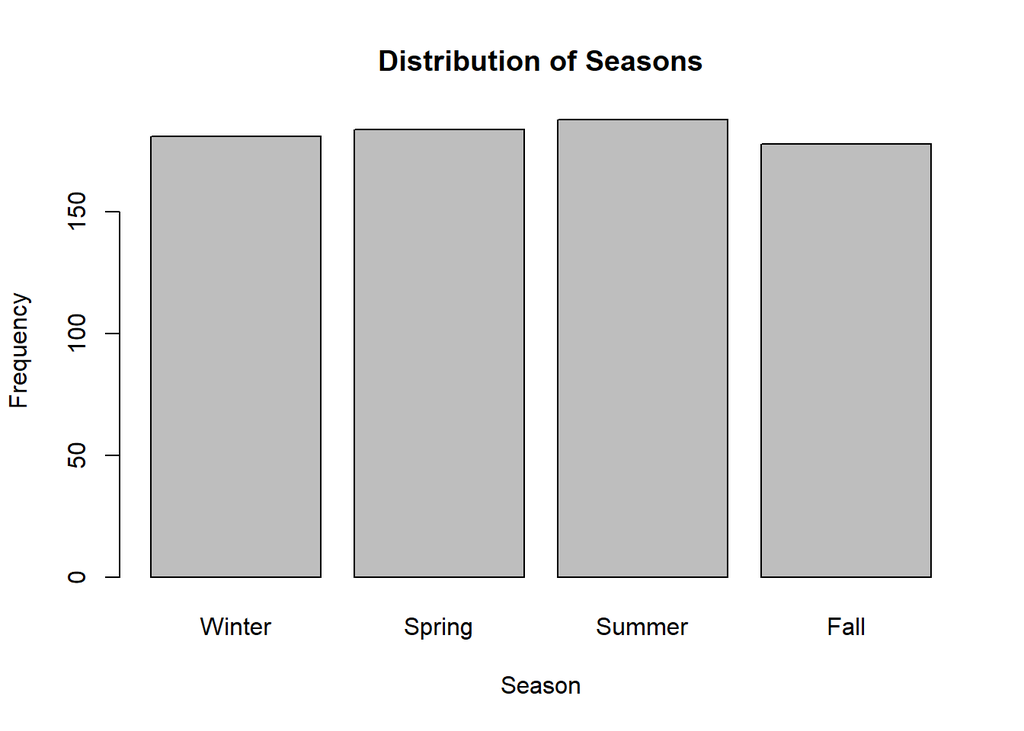

```r
# Bar chart
barplot(table(bike$season),
        main = "Distribution of Seasons",
        xlab = "Season",
        ylab = "Frequency")
```

Summer is the most common season with frequency 188 and relative frequency 0.2572. Fall is the least common with frequency 178 and relative frequency 0.2435. Winter and Spring have relative frequencies 0.2476 and 0.2517, respectively. The relative frequencies are very close to each other, so the distribution is approximately balanced. There are no rare or problematic categories.

### Weather Situation

```r
# Frequency table
table(bike$weathersit)
```

```
##
## Clear/Few Clouds      Mist/Cloudy  Light Snow/Rain
##              463              247               21
```

```r
# Relative-frequency table
table(bike$weathersit) / length(bike$weathersit)
```

```
##
## Clear/Few Clouds      Mist/Cloudy  Light Snow/Rain
##       0.63337893       0.33789330       0.02872777
```

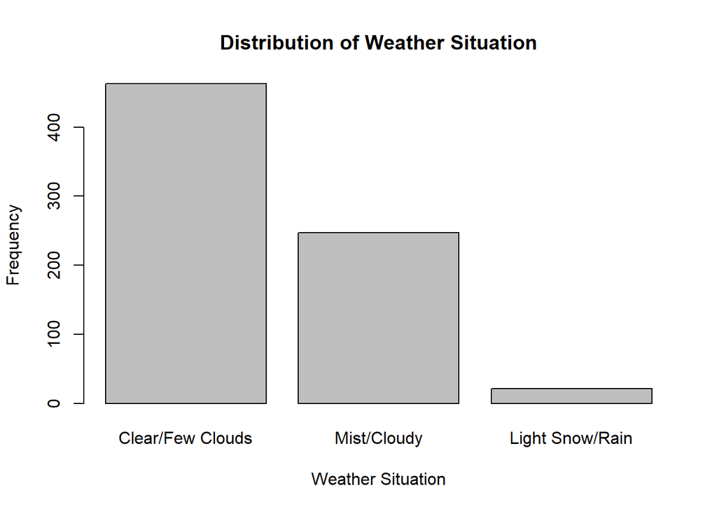

```r
# Bar chart
barplot(table(bike$weathersit),
        main = "Distribution of Weather Situation",
        xlab = "Weather Situation",
        ylab = "Frequency")
```

Clear/Few Clouds is the most common weather situation with frequency 463 and relative frequency 0.6334. Mist/Cloudy has frequency 247 and relative frequency 0.3379. Light Snow/Rain is the least common category with frequency 21 and relative frequency 0.0287. Therefore, the distribution is not balanced, and Light Snow/Rain is a rare category.

### Working Day

```r
# Frequency table
table(bike$workingday)
```

```
##
##  No Yes
## 231 500
```

```r
# Relative-frequency table
table(bike$workingday) / length(bike$workingday)
```

```
##
##        No       Yes
## 0.3160055 0.6839945
```

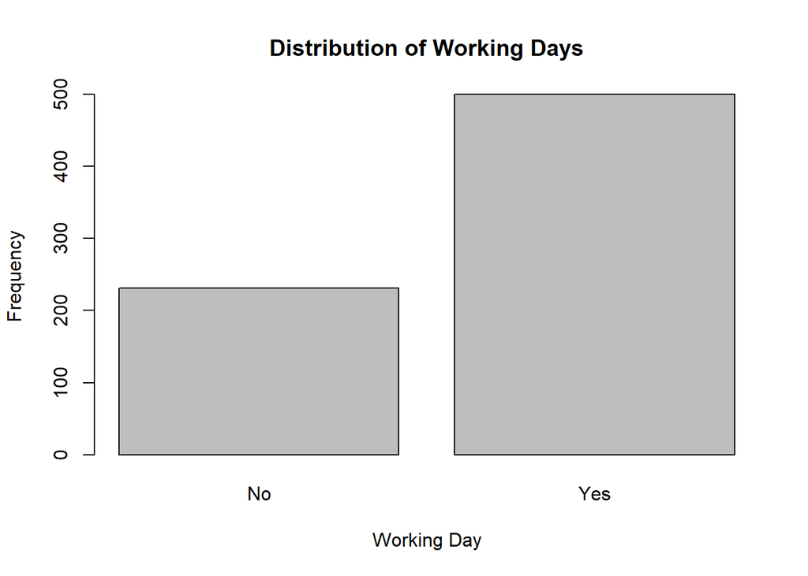

```r
# Bar chart
barplot(table(bike$workingday),
        main = "Distribution of Working Days",
        xlab = "Working Day",
        ylab = "Frequency")
```

Working days are more common, with frequency 500 and relative frequency 0.6840. Non-working days have frequency 231 and relative frequency 0.3160. Therefore, the distribution is not balanced, but neither category is rare.

### Weekday

```r
# Frequency table
table(bike$weekday)
```

```
##
##    Sunday    Monday   Tuesday Wednesday  Thursday    Friday  Saturday
##       105       105       104       104       104       104       105
```

```r
# Relative-frequency table
table(bike$weekday) / length(bike$weekday)
```

```
##
##    Sunday    Monday   Tuesday Wednesday  Thursday    Friday  Saturday
## 0.1436389 0.1436389 0.1422709 0.1422709 0.1422709 0.1422709 0.1436389
```

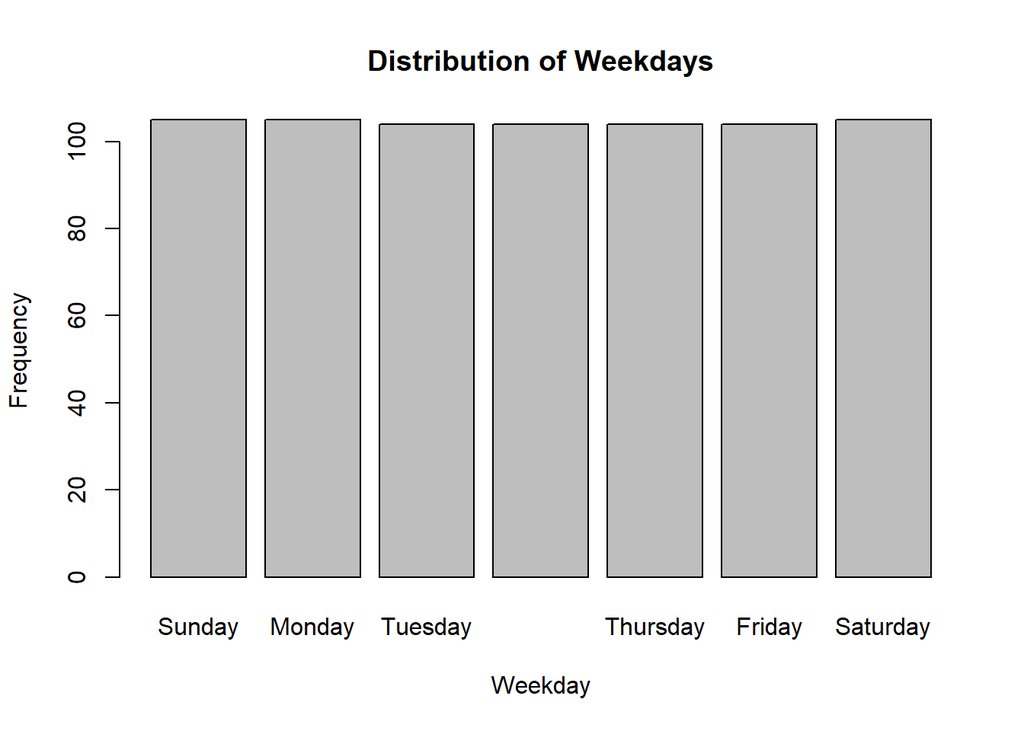

```r
# Bar chart
barplot(table(bike$weekday),
        main = "Distribution of Weekdays",
        xlab = "Weekday",
        ylab = "Frequency")
```

The distribution of weekdays is almost perfectly balanced. Sunday, Monday, and Saturday each have frequency 105 and relative frequency 0.1436. Tuesday, Wednesday, Thursday, and Friday each have frequency 104 and relative frequency 0.1423. There are no rare or problematic categories.

## 3.1 Interaction Between Categorical Variables

Two pairs of categorical variables were selected to investigate their association.

### Season and Weather Situation

The relationship between `season` and `weathersit` was investigated to see whether the distribution of weather situations changes across seasons.

```r
# Contingency table
season_weather <- table(bike$season, bike$weathersit)
season_weather
```

```
##
##          Clear/Few Clouds Mist/Cloudy Light Snow/Rain
##   Winter              111          66               4
##   Spring              113          68               3
##   Summer              136          48               4
##   Fall                103          65              10
```

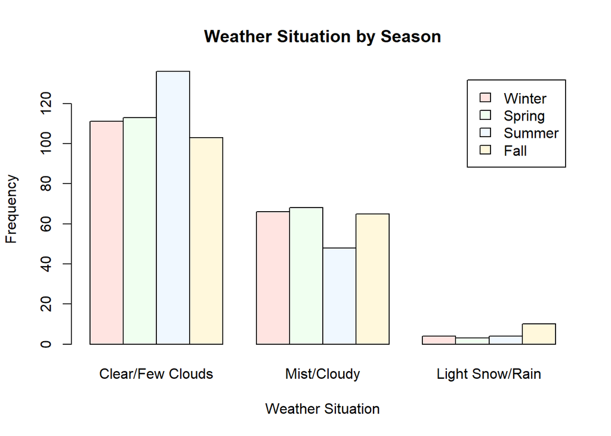

```r
# Comparative bar chart
barplot(season_weather,
        beside = TRUE,
        legend.text = TRUE,
        col = c("mistyrose", "honeydew", "aliceblue", "cornsilk"),
        main = "Weather Situation by Season",
        xlab = "Weather Situation",
        ylab = "Frequency")
```

Clear/Few Clouds is the most common weather situation in every season. Summer has the highest frequency of Clear/Few Clouds days, with 136 observations. Winter has 111, Spring has 113, and Fall has 103.

Mist/Cloudy occurs 66 times in Winter, 68 times in Spring, 48 times in Summer, and 65 times in Fall. Light Snow/Rain is rare in every season, but it occurs most frequently in Fall, with 10 observations, compared with 4 in Winter, 3 in Spring, and 4 in Summer.

Therefore, Clear/Few Clouds is dominant in every season, but the distribution of weather situations changes somewhat depending on the season.

### Weekday and Working Day

The relationship between `weekday` and `workingday` was investigated to see whether working-day status changes across the days of the week.

```r
# Contingency table
weekday_working <- table(bike$weekday, bike$workingday)
weekday_working
```

```
##
##              No Yes
##   Sunday    105   0
##   Monday     15  90
##   Tuesday     1 103
##   Wednesday   1 103
##   Thursday    2 102
##   Friday      2 102
##   Saturday  105   0
```

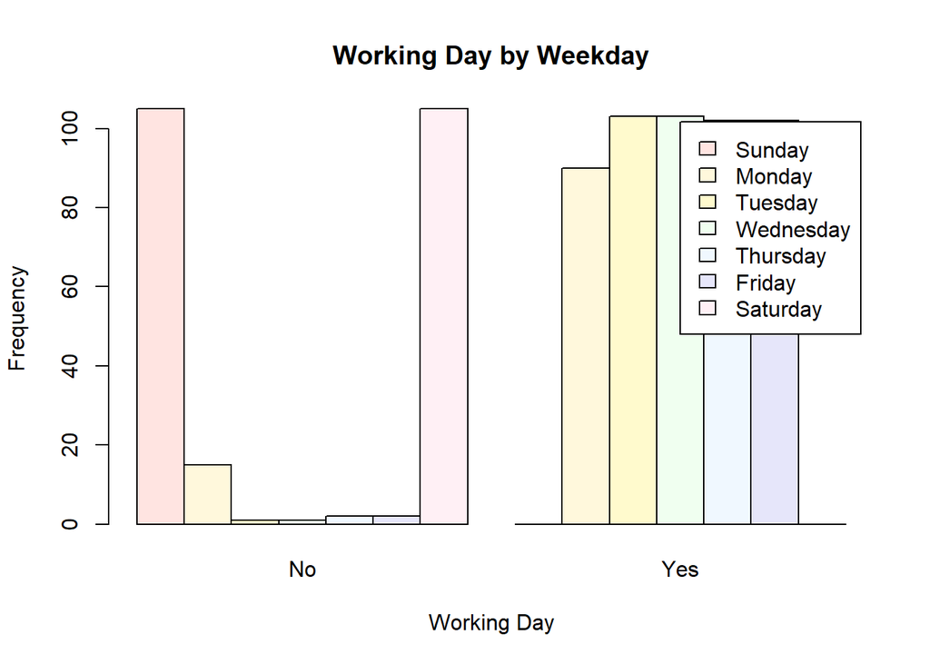

```r
# Comparative bar chart
barplot(weekday_working,
        beside = TRUE,
        legend.text = TRUE,
        col = c("mistyrose", "cornsilk", "lemonchiffon", "honeydew",
                "aliceblue", "lavender", "lavenderblush"),
        main = "Working Day by Weekday",
        xlab = "Working Day",
        ylab = "Frequency")
```

Working-day status changes clearly depending on the weekday. All 105 Sundays and all 105 Saturdays are non-working days. In contrast, most Monday through Friday observations are working days.

Monday has 90 working days and 15 non-working days. Tuesday and Wednesday each have 103 working days and 1 non-working day. Thursday and Friday each have 102 working days and 2 non-working days.

Therefore, there is a clear association between weekday and working-day status. Weekends are non-working days, while almost all weekdays are working days.

## 4. Analysis of Numerical Variables

Four important numerical variables were selected for analysis: `temp`, `hum`, `windspeed`, and `cnt`. These variables describe weather conditions and the total number of daily bike rentals.

For each variable, descriptive statistics, a histogram, a density plot, and a boxplot were used to examine the center, variability, distributional shape, skewness, and possible outliers.

```r
# Function for descriptive statistics
numerical_stats <- function(x) {

  five <- fivenum(x)

  c(
    Mean = mean(x),
    Median = median(x),
    Minimum = five[1],
    Maximum = five[5],
    Range = five[5] - five[1],
    Q1 = five[2],
    Q3 = five[4],
    IQR = five[4] - five[2],
    SD = sd(x),
    CV = sd(x) / mean(x)
  )
}

# Descriptive statistics
numerical_stats(bike$temp)
```

```
##      Mean    Median   Minimum   Maximum     Range        Q1        Q3       IQR
## 0.4953848 0.4983330 0.0591304 0.8616670 0.8025366 0.3370835 0.6554165 0.3183330
##        SD        CV
## 0.1830510 0.3695128
```

```r
numerical_stats(bike$hum)
```

```
##      Mean    Median   Minimum   Maximum     Range        Q1        Q3       IQR
## 0.6278941 0.6266670 0.0000000 0.9725000 0.9725000 0.5200000 0.7302085 0.2102085
##        SD        CV
## 0.1424291 0.2268362
```

```r
numerical_stats(bike$windspeed)
```

```
##       Mean     Median    Minimum    Maximum      Range         Q1         Q3
## 0.19048621 0.18097500 0.02239170 0.50746300 0.48507130 0.13495000 0.23321450
##        IQR         SD         CV
## 0.09826450 0.07749787 0.40684242
```

```r
numerical_stats(bike$cnt)
```

```
##         Mean       Median      Minimum      Maximum        Range           Q1
## 4504.3488372 4548.0000000   22.0000000 8714.0000000 8692.0000000 3152.0000000
##           Q3          IQR           SD           CV
## 5956.0000000 2804.0000000 1937.2114516    0.4300758
```

The quartiles are obtained using `fivenum()`, so they follow the quartile calculation used in the course. The interquartile range is calculated as $Q_3-Q_1$, and the coefficient of variation is calculated as $CV=s/\bar{x}$.

### Temperature

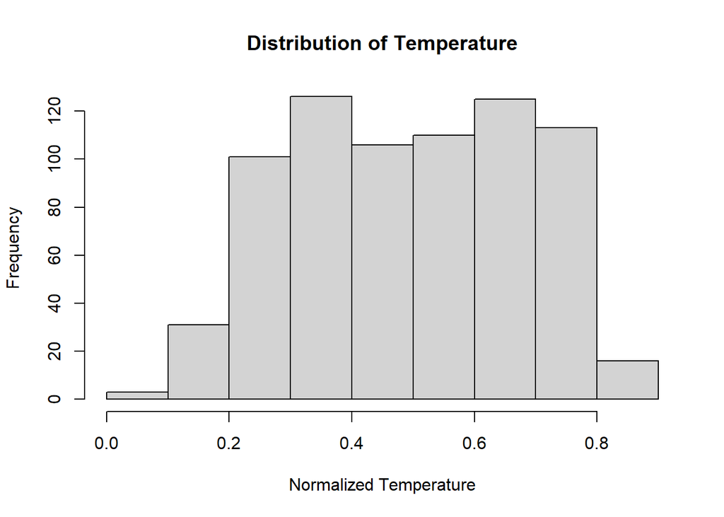

```r
hist(bike$temp,
     main = "Distribution of Temperature",
     xlab = "Normalized Temperature")
```

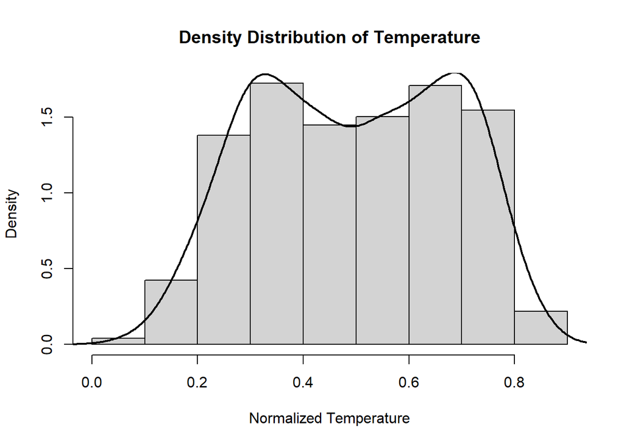

```r
hist(bike$temp,
     probability = TRUE,
     main = "Density Distribution of Temperature",
     xlab = "Normalized Temperature")

lines(density(bike$temp),
      lwd = 2)
```

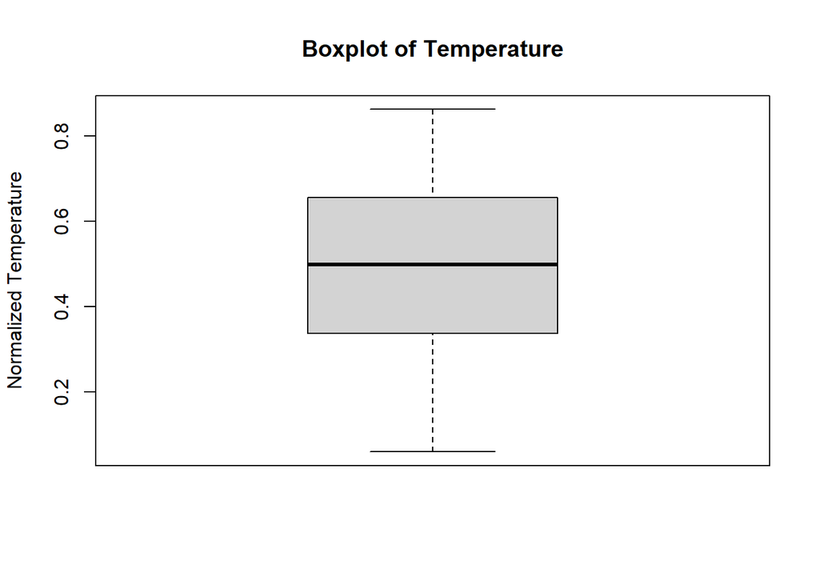

```r
boxplot(bike$temp,
        main = "Boxplot of Temperature",
        ylab = "Normalized Temperature")
```

```r
# Potential outliers
boxplot.stats(bike$temp)$out
```

```
## numeric(0)
```

The mean normalized temperature is 0.495 and the median is 0.498. These values are very close, indicating that the center of the distribution is around 0.50.

The histogram and density plot are fairly balanced overall and do not show strong skewness. The boxplot shows no potential outliers.

### Humidity

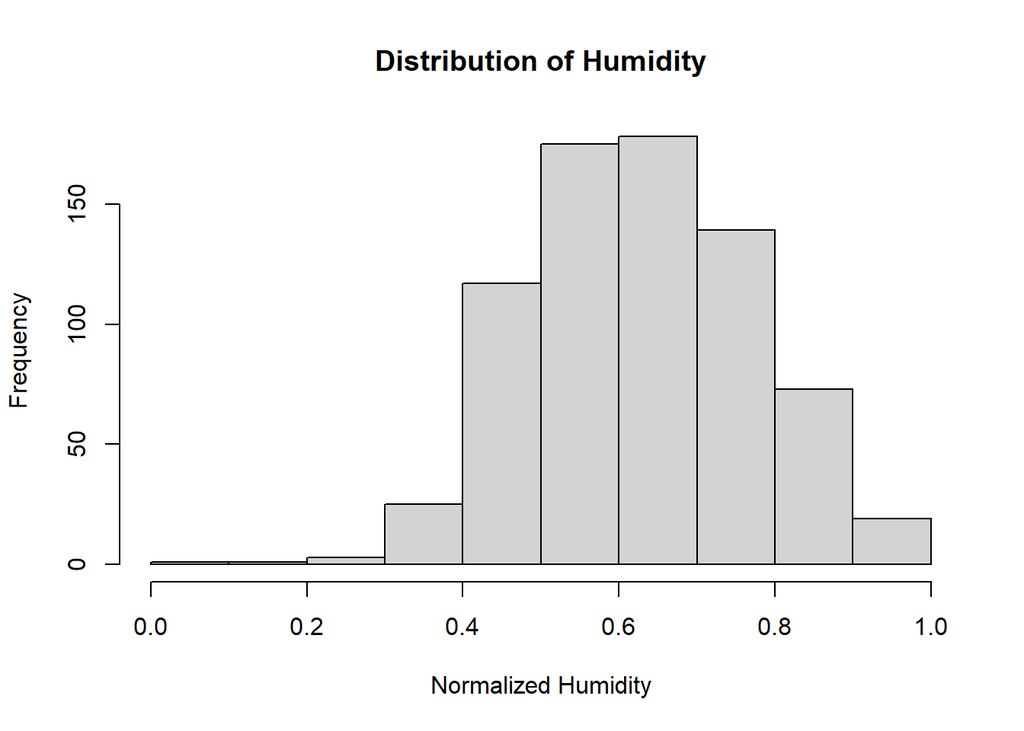

```r
hist(bike$hum,
     main = "Distribution of Humidity",
     xlab = "Normalized Humidity")
```

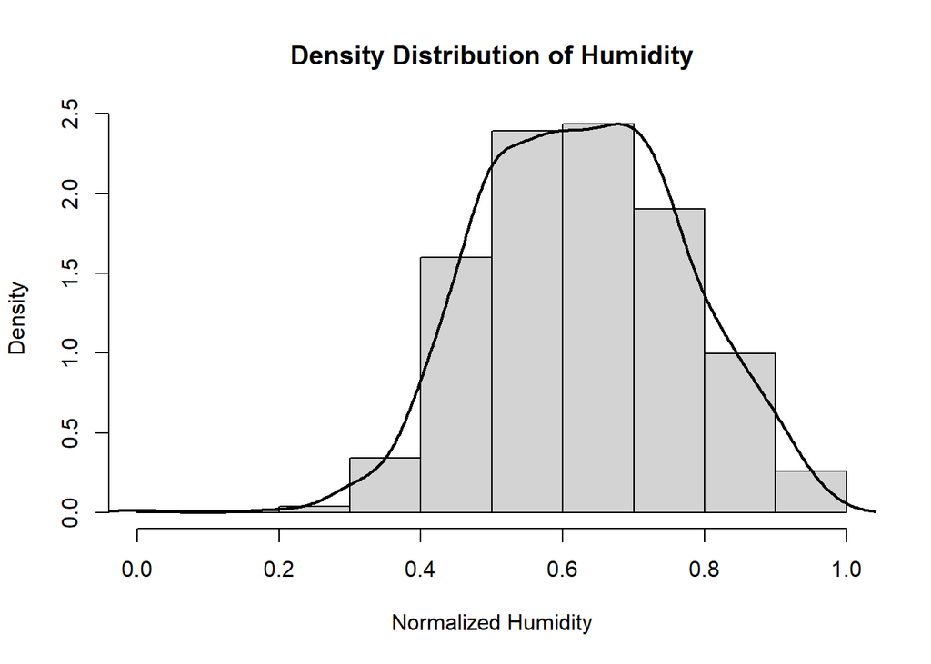

```r
hist(bike$hum,
     probability = TRUE,
     main = "Density Distribution of Humidity",
     xlab = "Normalized Humidity")

lines(density(bike$hum),
      lwd = 2)
```

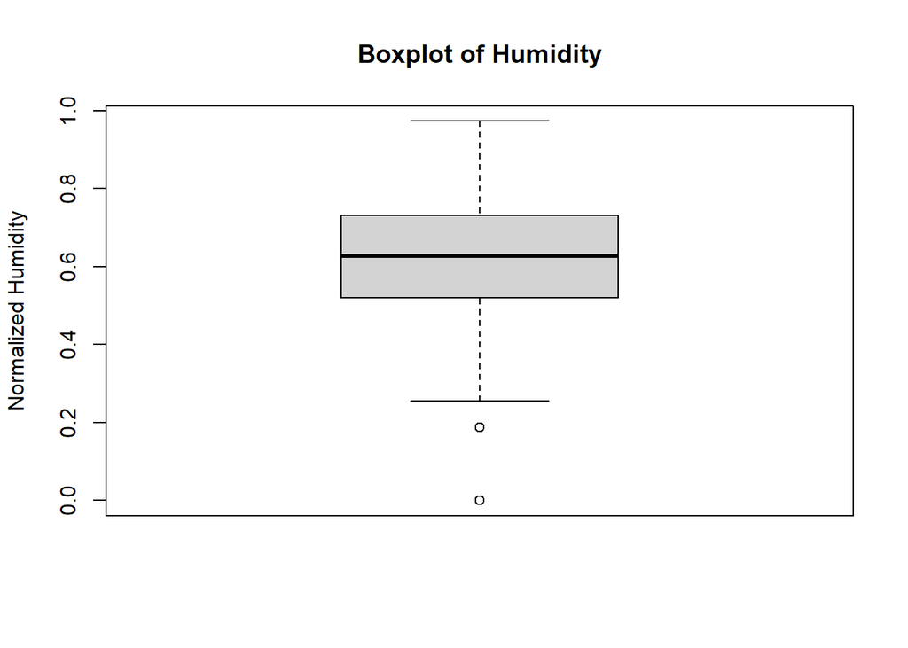

```r
boxplot(bike$hum,
        main = "Boxplot of Humidity",
        ylab = "Normalized Humidity")
```

```r
# Potential outliers
boxplot.stats(bike$hum)$out
```

```
## [1] 0.187917 0.000000
```

The mean normalized humidity is 0.628 and the median is 0.627, so the center of the distribution is around 0.63.

Most observations are concentrated around 0.5 to 0.7. The histogram and density plot show the overall shape of the distribution, while the boxplot identifies two potential low outliers.

### Wind Speed

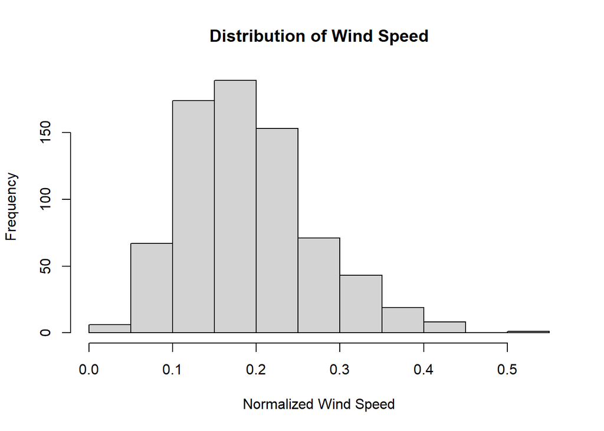

```r
hist(bike$windspeed,
     main = "Distribution of Wind Speed",
     xlab = "Normalized Wind Speed")
```

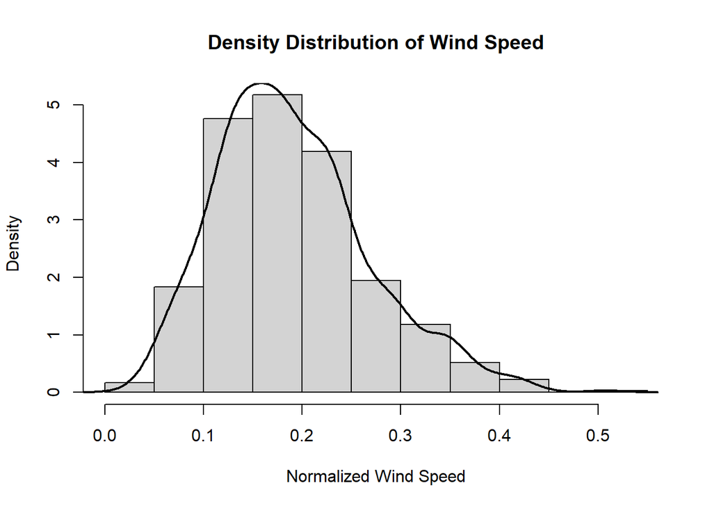

```r
hist(bike$windspeed,
     probability = TRUE,
     main = "Density Distribution of Wind Speed",
     xlab = "Normalized Wind Speed")

lines(density(bike$windspeed),
      lwd = 2)
```

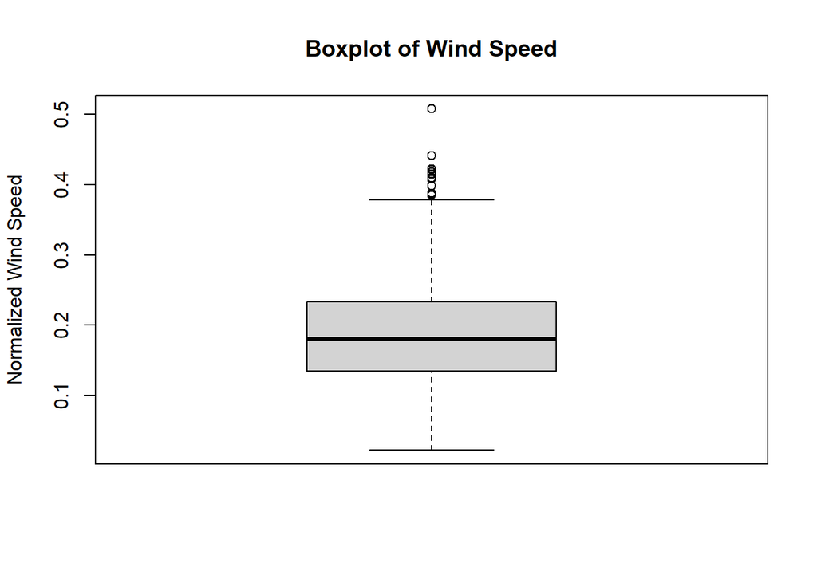

```r
boxplot(bike$windspeed,
        main = "Boxplot of Wind Speed",
        ylab = "Normalized Wind Speed")
```

```r
# Potential outliers
boxplot.stats(bike$windspeed)$out
```

```
##  [1] 0.417908 0.507463 0.385571 0.388067 0.422275 0.415429 0.409212 0.421642
##  [9] 0.441563 0.414800 0.386821 0.398008 0.407346
```

The mean normalized wind speed is 0.190 and the median is 0.181. Since the mean is slightly larger than the median, this is consistent with a right-skewed distribution.

The histogram and density plot show a longer upper tail, which also indicates right skewness. The boxplot identifies 13 potential high outliers.

### Total Bike Rentals

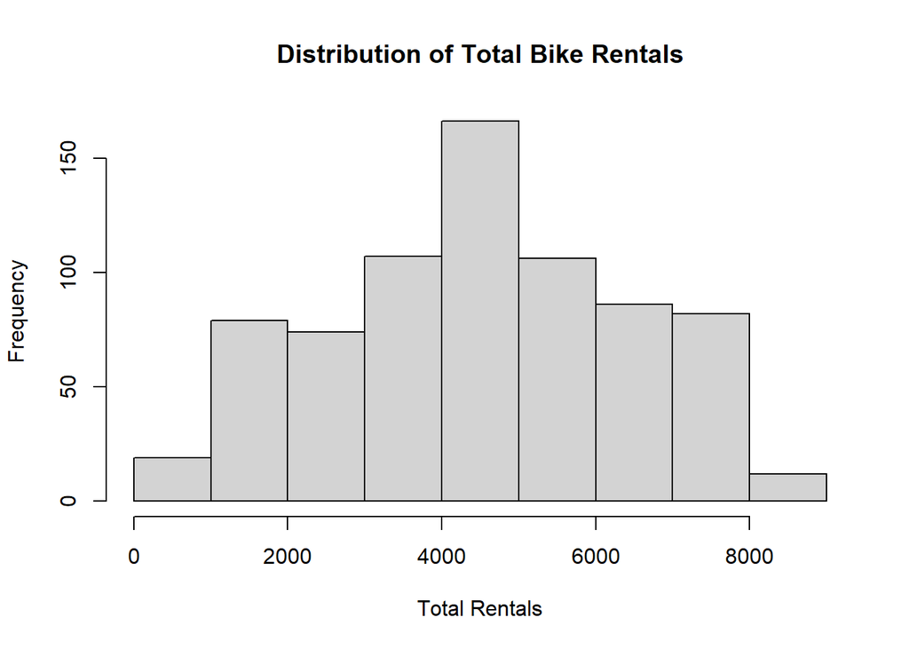

```r
hist(bike$cnt,
     main = "Distribution of Total Bike Rentals",
     xlab = "Total Rentals")
```

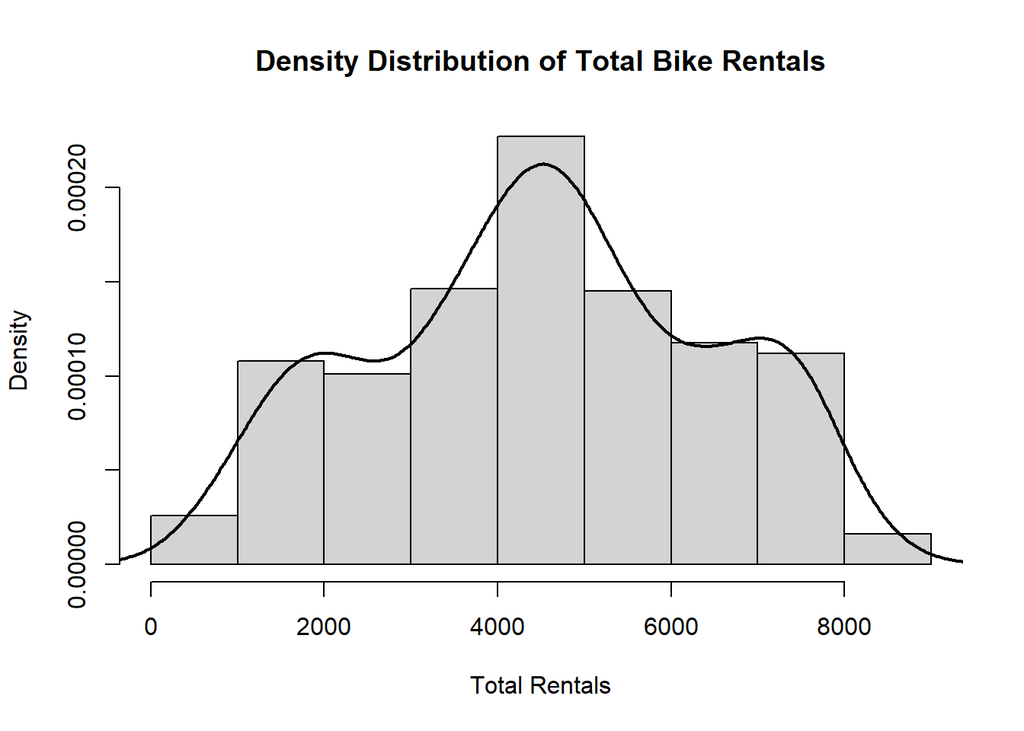

```r
hist(bike$cnt,
     probability = TRUE,
     main = "Density Distribution of Total Bike Rentals",
     xlab = "Total Rentals")

lines(density(bike$cnt),
      lwd = 2)
```

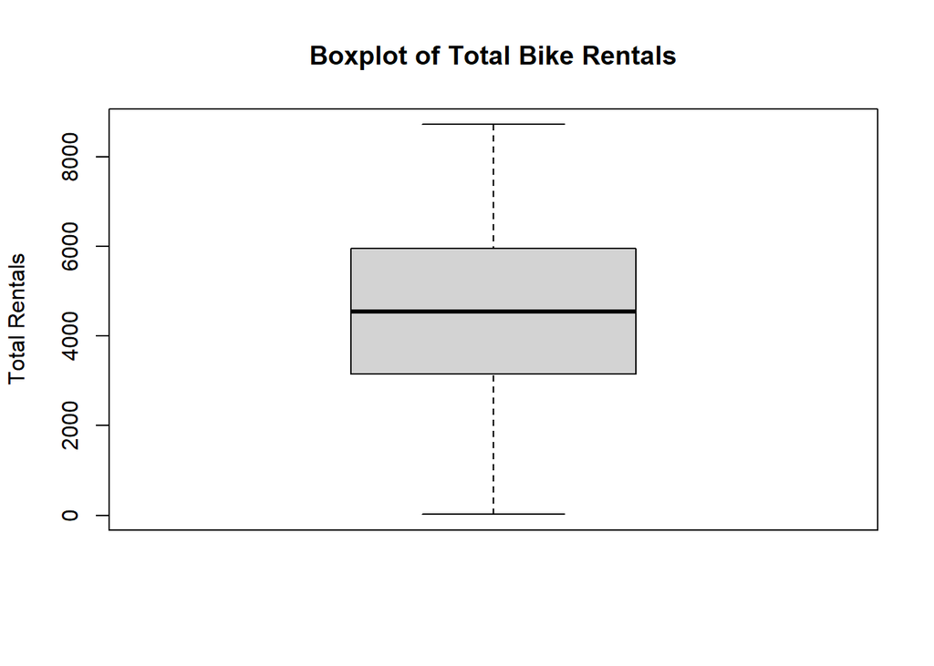

```r
boxplot(bike$cnt,
        main = "Boxplot of Total Bike Rentals",
        ylab = "Total Rentals")
```

```r
# Potential outliers
boxplot.stats(bike$cnt)$out
```

```
## integer(0)
```

The mean number of daily bike rentals is 4504.349 and the median is 4548. Therefore, the center of the distribution is approximately 4500 rentals per day.

The histogram and density plot are fairly balanced around the center and do not show strong skewness. The boxplot shows no potential outliers.

### Overall Interpretation

Temperature and total bike rentals have relatively balanced distributions with no boxplot outliers. Humidity contains two potential low outliers, while wind speed is right-skewed and contains several potential high outliers.

The coefficient of variation provides an additional measure of relative variability and allows the variability of the numerical variables to be compared relative to their means.

## 5. Numerical Variables by Categories

This section investigates whether total daily bike rentals differ across seasons and weather conditions. For each comparison, grouped summary statistics and side-by-side boxplots are used to compare location, variability, and distributional shape.

### 5.1 Total Bike Rentals by Season

The distribution of total daily bike rentals (`cnt`) is compared across the four seasons.

```r
# Function for lecture-style IQR
lecture_IQR <- function(x) {
  five <- fivenum(x)
  five[4] - five[2]
}

# Grouped summary statistics by season
season_summary <- data.frame(
  Season = levels(bike$season),
  Mean = as.numeric(tapply(bike$cnt, bike$season, mean)),
  Median = as.numeric(tapply(bike$cnt, bike$season, median)),
  SD = as.numeric(tapply(bike$cnt, bike$season, sd)),
  IQR = as.numeric(tapply(bike$cnt, bike$season, lecture_IQR)),
  Minimum = as.numeric(tapply(bike$cnt, bike$season, min)),
  Maximum = as.numeric(tapply(bike$cnt, bike$season, max))
)

season_summary
```

```
##   Season     Mean Median       SD    IQR Minimum Maximum
## 1 Winter 2604.133 2209.0 1399.942 1918.0     431    7836
## 2 Spring 4992.332 4941.5 1695.977 2388.0     795    8362
## 3 Summer 5644.303 5353.5 1459.800 2358.5    1115    8714
## 4   Fall 4728.163 4634.5 1699.615 2015.0      22    8555
```

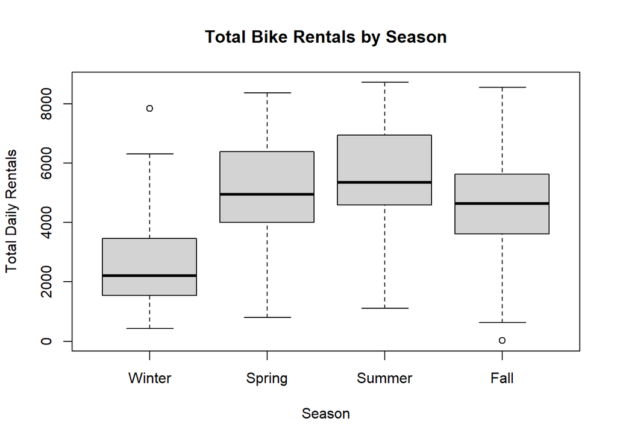

```r
# Side-by-side boxplot
boxplot(cnt ~ season,
        data = bike,
        main = "Total Bike Rentals by Season",
        xlab = "Season",
        ylab = "Total Daily Rentals")
```

The grouped summaries and boxplot are used to compare the center of the rental distributions across seasons using the mean and median. The standard deviation and interquartile range are used to compare variability. The boxplot also helps identify differences in distributional shape and possible unusual observations.

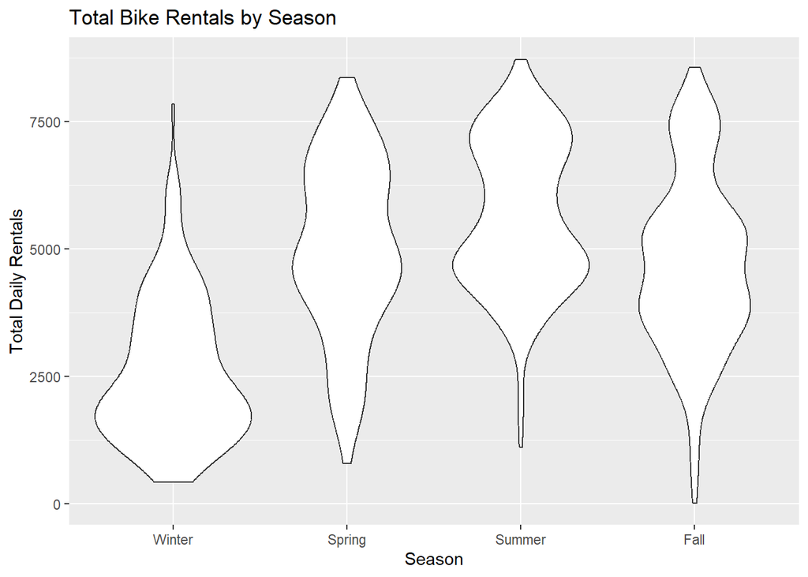

```r
# Violin plot of total bike rentals by season
library(ggplot2)

ggplot(bike, aes(x = season, y = cnt)) +
  geom_violin() +
  labs(title = "Total Bike Rentals by Season",
       x = "Season",
       y = "Total Daily Rentals")
```

The violin plot provides an additional view of the distribution of total bike rentals across seasons. Wider parts of each violin represent ranges where more observations are concentrated. This helps compare the distributional shapes across seasons and complements the information provided by the side-by-side boxplot.

### 5.2 Total Bike Rentals by Weather Situation

The distribution of total daily bike rentals is also compared across weather conditions.

```r
# Grouped summary statistics by weather situation
weather_summary <- data.frame(
  Weather = levels(bike$weathersit),
  Mean = as.numeric(tapply(bike$cnt, bike$weathersit, mean)),
  Median = as.numeric(tapply(bike$cnt, bike$weathersit, median)),
  SD = as.numeric(tapply(bike$cnt, bike$weathersit, sd)),
  IQR = as.numeric(tapply(bike$cnt, bike$weathersit, lecture_IQR)),
  Minimum = as.numeric(tapply(bike$cnt, bike$weathersit, min)),
  Maximum = as.numeric(tapply(bike$cnt, bike$weathersit, max))
)

weather_summary
```

```
##            Weather     Mean Median       SD  IQR Minimum Maximum
## 1 Clear/Few Clouds 4876.786   4844 1879.484 2822     431    8714
## 2      Mist/Cloudy 4035.862   4040 1809.110 2583     605    8362
## 3  Light Snow/Rain 1803.286   1817 1240.284 1719      22    4639
```

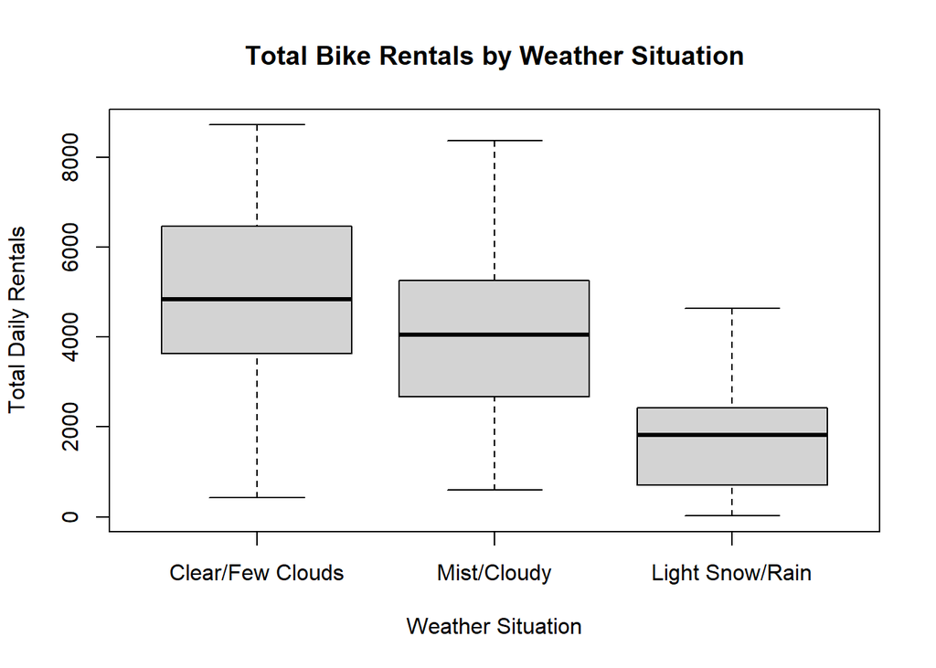

```r
# Side-by-side boxplot
boxplot(cnt ~ weathersit,
        data = bike,
        main = "Total Bike Rentals by Weather Situation",
        xlab = "Weather Situation",
        ylab = "Total Daily Rentals")
```

The grouped summaries and boxplot allow comparison of the location, spread, and shape of daily bike-rental distributions across weather categories.

## 6. Relationships Between Numerical Variables

Two pairs of numerical variables were investigated: temperature with total bike rentals, and humidity with total bike rentals. Scatterplots, correlation coefficients, and covariances were used to examine the direction and strength of the linear relationships.

### 6.1 Temperature and Total Bike Rentals

```r
# Correlation and covariance
cor(bike$temp, bike$cnt)
```

```
## [1] 0.627494
```

```r
cov(bike$temp, bike$cnt)
```

```
## [1] 222.5147
```

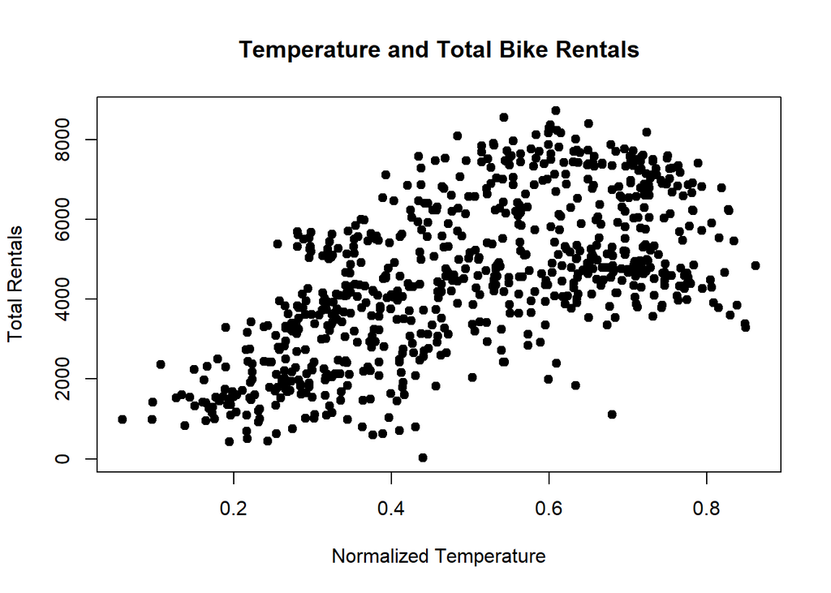

```r
# Scatterplot
plot(bike$temp, bike$cnt,
     main = "Temperature and Total Bike Rentals",
     xlab = "Normalized Temperature",
     ylab = "Total Rentals",
     pch = 19)
```

The correlation between normalized temperature and total bike rentals is 0.6275. Since $0.6 \leq |\rho| < 0.8$, there is a **strong positive linear relationship** between temperature and total bike rentals. The positive sign indicates an increasing trend: higher temperatures tend to be associated with higher bike rentals.

The covariance is 222.515. Its positive sign is also consistent with an increasing relationship between temperature and total rentals.

The scatterplot shows an overall increasing pattern, although the observations are fairly spread out. The relationship is not perfectly linear. There are some observations with relatively low rental counts compared with other days having similar temperatures, but there is no single extreme observation that appears to dominate the relationship.

### 6.2 Humidity and Total Bike Rentals

```r
# Correlation and covariance
cor(bike$hum, bike$cnt)
```

```
## [1] -0.1006586
```

```r
cov(bike$hum, bike$cnt)
```

```
## [1] -27.77323
```

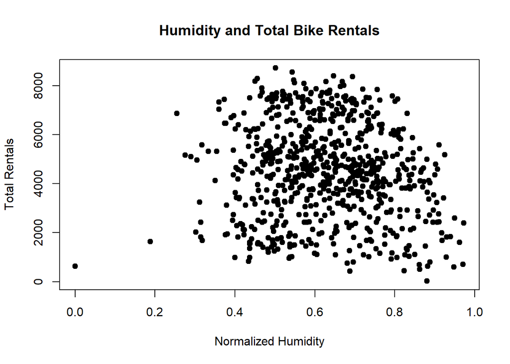

```r
# Scatterplot
plot(bike$hum, bike$cnt,
     main = "Humidity and Total Bike Rentals",
     xlab = "Normalized Humidity",
     ylab = "Total Rentals",
     pch = 19)
```

The correlation between normalized humidity and total bike rentals is -0.1007. Since $0 < |\rho| < 0.2$, there is a **very weak negative linear relationship** between humidity and total bike rentals. The negative sign indicates a decreasing trend, but the linear relationship is very weak.

The covariance is -27.773. Its negative sign is consistent with the decreasing direction of the relationship.

The scatterplot shows considerable spread and no strong linear pattern. Therefore, humidity has a much weaker linear relationship with total bike rentals than temperature. There are some observations with very low humidity, but no single observation appears to dominate the overall relationship.

### 6.3 Temperature and Total Bike Rentals by Season

Season was used to investigate whether the relationship between temperature and total bike rentals changes across groups.

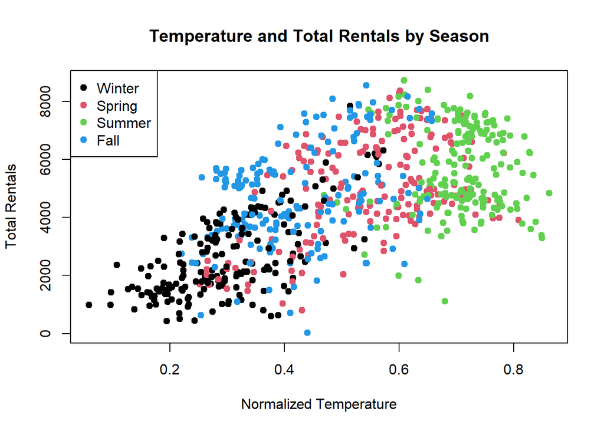

```r
# Scatterplot by season
plot(bike$temp, bike$cnt,
     col = as.numeric(bike$season),
     pch = 19,
     main = "Temperature and Total Rentals by Season",
     xlab = "Normalized Temperature",
     ylab = "Total Rentals")

legend("topleft",
       legend = levels(bike$season),
       col = 1:length(levels(bike$season)),
       pch = 19)
```

```r
# Correlation in Winter
cor(bike$temp[bike$season == "Winter"],
    bike$cnt[bike$season == "Winter"])
```

```
## [1] 0.6692022
```

```r
# Correlation in Spring
cor(bike$temp[bike$season == "Spring"],
    bike$cnt[bike$season == "Spring"])
```

```
## [1] 0.4768842
```

```r
# Correlation in Summer
cor(bike$temp[bike$season == "Summer"],
    bike$cnt[bike$season == "Summer"])
```

```
## [1] -0.03281876
```

```r
# Correlation in Fall
cor(bike$temp[bike$season == "Fall"],
    bike$cnt[bike$season == "Fall"])
```

```
## [1] 0.3976656
```

The relationship between temperature and total bike rentals differs across seasons.

The correlation in Winter is 0.6692. Since $0.6 \leq |\rho| < 0.8$, there is a **strong positive linear relationship** between temperature and total rentals in Winter.

The correlation in Spring is 0.4769. Since $0.4 \leq |\rho| < 0.6$, there is a **moderate positive linear relationship**.

The correlation in Summer is -0.0328. Since $0 < |\rho| < 0.2$, there is a **very weak negative linear relationship**.

The correlation in Fall is 0.3977. Since $0.2 \leq |\rho| < 0.4$, there is a **weak positive linear relationship**.

Therefore, both the direction and strength of the linear relationship between temperature and total bike rentals change across seasons. The strongest linear relationship is observed in Winter, while the relationship is very weak in Summer. This shows that the overall positive relationship between temperature and total rentals is not the same within every season.

## 7. Distributional Analysis and QQ Plots

Normalized temperature (`temp`) was selected for distributional analysis. A Normal distribution is considered as a possible theoretical distribution. A histogram and Normal QQ plot are used to investigate whether the empirical distribution of temperature is reasonably consistent with a Normal distribution.

### 7.1 Normal Distribution and QQ Plot

First, numerical summaries and a histogram are used to examine the empirical distribution of normalized temperature.

```r
# Numerical summary of temperature
temp_five <- fivenum(bike$temp)

mean(bike$temp)
```

```
## [1] 0.4953848
```

```r
median(bike$temp)
```

```
## [1] 0.498333
```

```r
temp_five
```

```
## [1] 0.0591304 0.3370835 0.4983330 0.6554165 0.8616670
```

```r
temp_five[4] - temp_five[2]
```

```
## [1] 0.318333
```

```r
sd(bike$temp)
```

```
## [1] 0.183051
```

The mean normalized temperature is 0.495 and the median is 0.498, so the two measures of center are very close. The first quartile is 0.337 and the third quartile is 0.655, giving an IQR of 0.318. The standard deviation is 0.183.

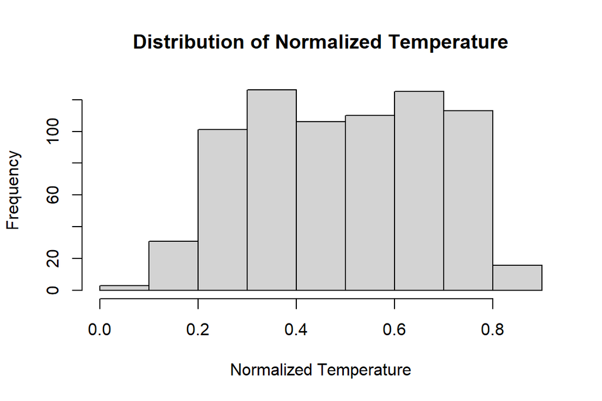

```r
# Histogram of normalized temperature
hist(bike$temp,
     main = "Distribution of Normalized Temperature",
     xlab = "Normalized Temperature")
```

The histogram shows the empirical distribution of normalized temperature. The distribution is fairly balanced overall, but it does not have a clear bell-shaped Normal form. A Normal QQ plot is used for a more direct comparison with a Normal distribution.

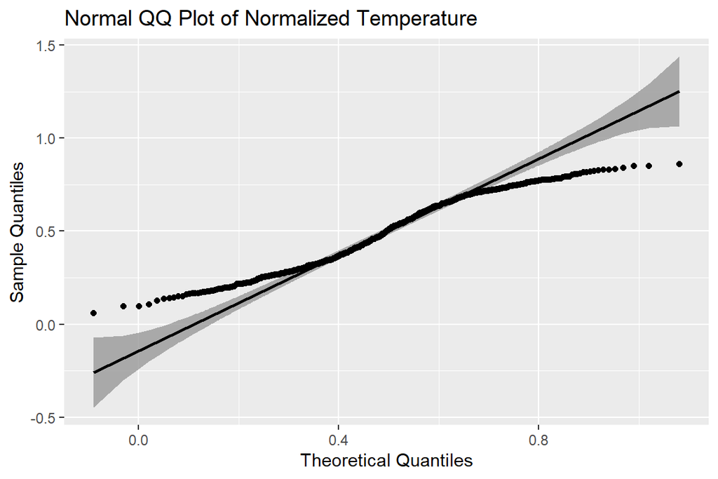

```r
# Packages used for QQ plot with a QQ band
require(ggplot2)
require(qqplotr)
# Data for QQ plot
temp_data <- data.frame(variable = bike$temp)

# Normal QQ plot with QQ band
ggplot(data = temp_data,
       mapping = aes(sample = variable)) +
  stat_qq_band() +
  stat_qq_line() +
  stat_qq_point() +
  labs(title = "Normal QQ Plot of Normalized Temperature",
       x = "Theoretical Quantiles",
       y = "Sample Quantiles")
```

The QQ plot shows systematic departures from the Normal reference line, particularly in the tails. Some observations also depart from the QQ band. The deviations are not limited to only one or two isolated observations.

Therefore, the empirical distribution of normalized temperature does not appear to be well described by a Normal distribution. The center is closer to the expected Normal pattern than the tails, but the systematic departures indicate that the overall distribution is not reasonably consistent with Normality.

### 7.2 Distribution of Temperature Across Seasons

The distribution of normalized temperature is compared across the four seasons to investigate whether the distributions differ in location, spread, skewness, tails, and overall shape.

```r
# Function for lecture-style IQR
lecture_IQR <- function(x) {
  five <- fivenum(x)
  five[4] - five[2]
}

# Numerical summaries of temperature by season
temperature_season_summary <- data.frame(
  Mean = tapply(bike$temp, bike$season, mean),
  Median = tapply(bike$temp, bike$season, median),
  SD = tapply(bike$temp, bike$season, sd),
  IQR = tapply(bike$temp, bike$season, lecture_IQR),
  Minimum = tapply(bike$temp, bike$season, min),
  Maximum = tapply(bike$temp, bike$season, max)
)

round(temperature_season_summary, 3)
```

```
##         Mean Median    SD   IQR Minimum Maximum
## Winter 0.298  0.286 0.103 0.139   0.059   0.573
## Spring 0.544  0.562 0.123 0.174   0.253   0.808
## Summer 0.706  0.715 0.071 0.084   0.469   0.862
## Fall   0.423  0.409 0.108 0.183   0.221   0.657
```

The centers of the temperature distributions differ across seasons. Summer has the highest mean temperature at 0.706, followed by Spring at 0.544, Fall at 0.423, and Winter at 0.298.

The variability also differs. Summer has the smallest standard deviation of 0.071 and the smallest IQR of 0.084, so Summer temperatures have the smallest spread. Fall has the largest IQR of 0.183, while Spring has the largest standard deviation of 0.123.

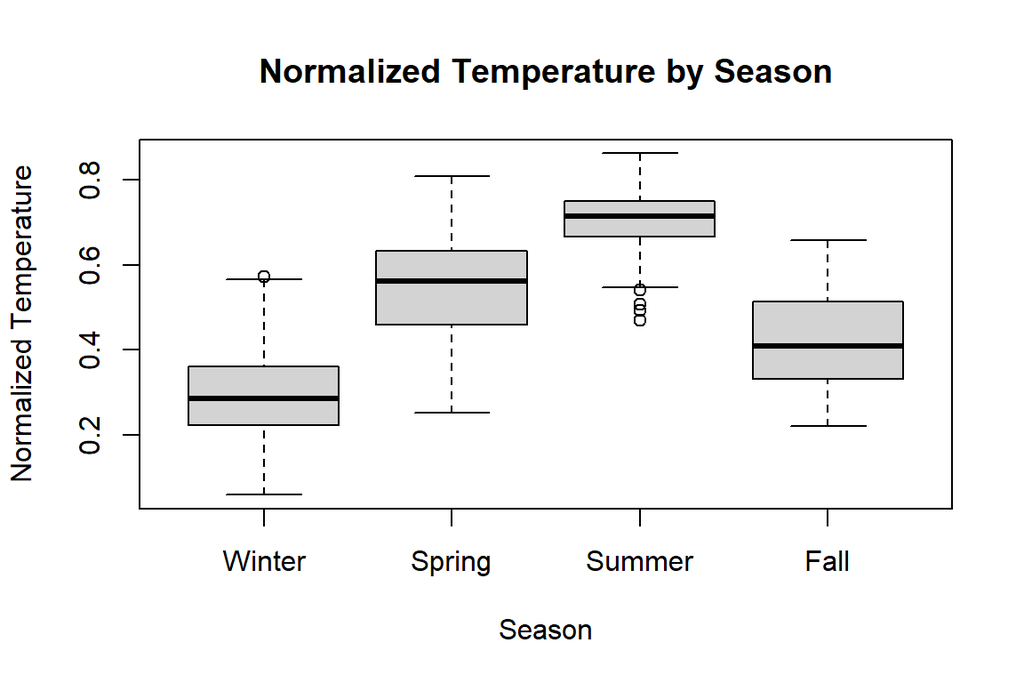

```r
# Side-by-side boxplots
boxplot(temp ~ season,
        data = bike,
        main = "Normalized Temperature by Season",
        xlab = "Season",
        ylab = "Normalized Temperature")
```

The boxplots show clear differences in location and spread across the four seasons. Summer has the highest center and the smallest spread, while Winter has the lowest center. Spring and Fall have intermediate centers and larger spreads than Summer.

The Summer boxplot shows several potentially unusual low temperature observations. Winter also shows a possible unusually high observation. These observations were retained because there is no evidence that they are data-entry errors.

### Normal QQ Plots by Season

Normal QQ plots are used to examine the temperature distribution within each season separately.

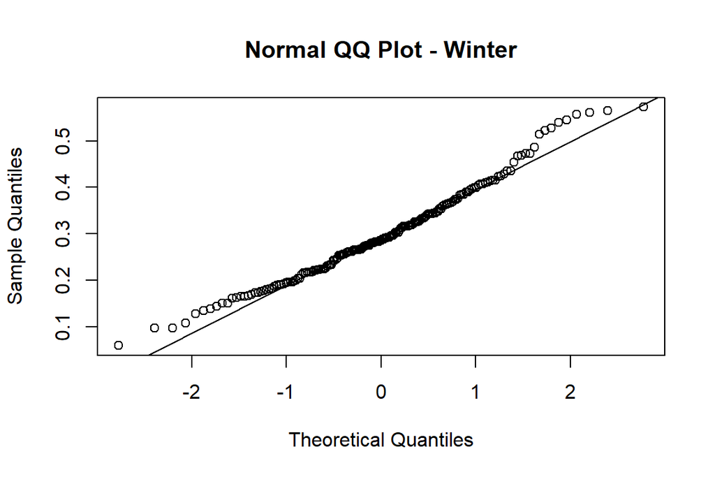

```r
# Winter
qqnorm(bike$temp[bike$season == "Winter"],
       main = "Normal QQ Plot - Winter")

qqline(bike$temp[bike$season == "Winter"])
```

For Winter, the points are relatively close to the reference line through much of the center, but there are systematic deviations in the tails. Therefore, the Winter distribution shows some departure from Normality.

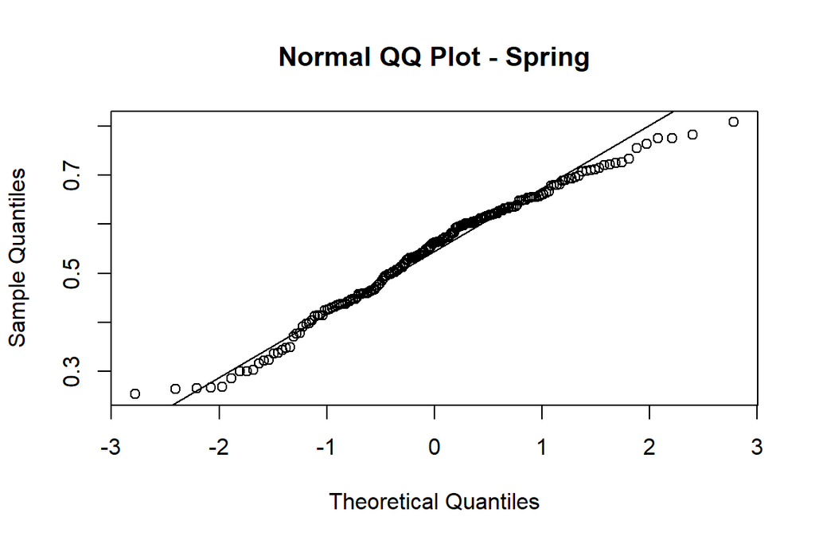

```r
# Spring
qqnorm(bike$temp[bike$season == "Spring"],
       main = "Normal QQ Plot - Spring")

qqline(bike$temp[bike$season == "Spring"])
```

For Spring, many of the points in the center are relatively close to the reference line, while deviations are more noticeable in the tails. Therefore, the center is more consistent with a Normal distribution than the tails.

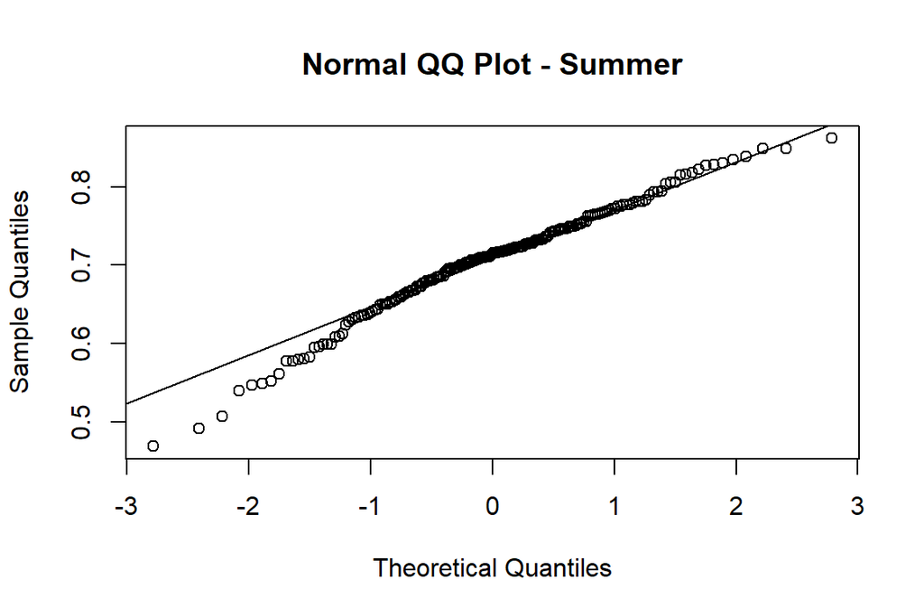

```r
# Summer
qqnorm(bike$temp[bike$season == "Summer"],
       main = "Normal QQ Plot - Summer")

qqline(bike$temp[bike$season == "Summer"])
```

For Summer, the central observations are relatively close to the reference line, but there is a clear departure in the lower tail. These lower-tail observations are also visible as potentially unusual observations in the Summer boxplot.

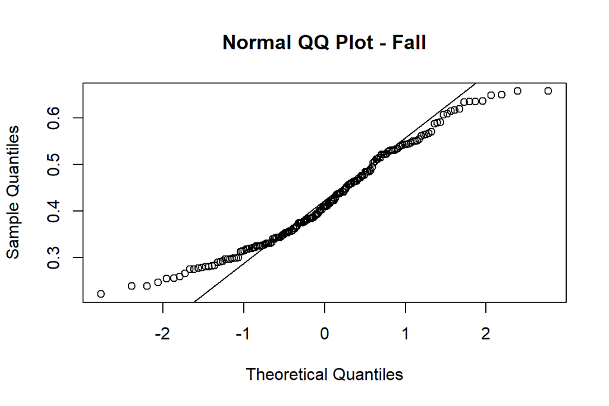

```r
# Fall
qqnorm(bike$temp[bike$season == "Fall"],
       main = "Normal QQ Plot - Fall")

qqline(bike$temp[bike$season == "Fall"])
```

For Fall, the QQ plot shows systematic curvature and deviations from the reference line in both tails. Therefore, the Fall temperature distribution does not appear to be closely consistent with a Normal distribution.

Overall, the temperature distributions cannot reasonably be considered the same across the four seasons. They differ clearly in location and spread, and the QQ plots also show differences in distributional shape and tail behavior. Summer is warmer and less variable, while Winter is colder. The seasonal differences also help explain why the combined temperature distribution is not well described by a single Normal distribution.